# Final Project Report

Damin Park, Diane Kim

12/15/21

### Front Matter

```r
# clean up the RStudio environment
rm(list = ls())

# load all packages
library(tidyverse)
library(readr)
library(mosaic)
```

### Data Access

```r
# import data
MentalHealthTech <- read.csv("survey.csv")
Students <- read.csv("mental_health_poll_updated.csv")
States <- read.csv("states.csv")
```

## Guiding Question

How does mental health affect students and people in the workplace?

Data Intake:  
Using the glimpse function, we can look at the two data sets being Mental Health  
in Tech provided by Kaggle and Teen Stress & Mental Health Poll on After School  
provided by data.world. The first is labeled “MentalHealthTech” and the second  
data set is labeled “Students”.

The distinct function was used to see how many different distinct types of  
“Question” and “Event.Category” there was in the Students data set.

```r
MentalHealthTech %>%
  glimpse()
```

```
Rows: 1,259
Columns: 27
$ Timestamp                 <chr> "2014-08-27 11:29:31", "2014-08-27 11:29:37", "2014-08-27 11:29:44"…
$ Age                       <dbl> 37, 44, 32, 31, 31, 33, 35, 39, 42, 23, 31, 29, 42, 36, 27, 29, 23,…
$ Gender                    <chr> "Female", "M", "Male", "Male", "Male", "Male", "Female", "M", "Fema…
$ Country                   <chr> "United States", "United States", "Canada", "United Kingdom", "Unit…
$ state                     <chr> "IL", "IN", NA, NA, "TX", "TN", "MI", NA, "IL", NA, "OH", NA, "CA",…
$ self_employed             <chr> NA, NA, NA, NA, NA, NA, NA, NA, NA, NA, NA, NA, NA, NA, NA, NA, NA,…
$ family_history            <chr> "No", "No", "No", "Yes", "No", "Yes", "Yes", "No", "Yes", "No", "No…
$ treatment                 <chr> "Yes", "No", "No", "Yes", "No", "No", "Yes", "No", "Yes", "No", "Ye…
$ work_interfere            <chr> "Often", "Rarely", "Rarely", "Often", "Never", "Sometimes", "Someti…
$ no_employees              <chr> "6-25", "More than 1000", "6-25", "26-100", "100-500", "6-25", "1-5…
$ remote_work               <chr> "No", "No", "No", "No", "Yes", "No", "Yes", "Yes", "No", "No", "Yes…
$ tech_company              <chr> "Yes", "No", "Yes", "Yes", "Yes", "Yes", "Yes", "Yes", "Yes", "Yes"…
$ benefits                  <chr> "Yes", "Don't know", "No", "No", "Yes", "Yes", "No", "No", "Yes", "…
$ care_options              <chr> "Not sure", "No", "No", "Yes", "No", "Not sure", "No", "Yes", "Yes"…
$ wellness_program          <chr> "No", "Don't know", "No", "No", "Don't know", "No", "No", "No", "No…
$ seek_help                 <chr> "Yes", "Don't know", "No", "No", "Don't know", "Don't know", "No", …
$ anonymity                 <chr> "Yes", "Don't know", "Don't know", "No", "Don't know", "Don't know"…
$ leave                     <chr> "Somewhat easy", "Don't know", "Somewhat difficult", "Somewhat diff…
$ mental_health_consequence <chr> "No", "Maybe", "No", "Yes", "No", "No", "Maybe", "No", "Maybe", "No…
$ phys_health_consequence   <chr> "No", "No", "No", "Yes", "No", "No", "Maybe", "No", "No", "No", "No…
$ coworkers                 <chr> "Some of them", "No", "Yes", "Some of them", "Some of them", "Yes",…
$ supervisor                <chr> "Yes", "No", "Yes", "No", "Yes", "Yes", "No", "No", "Yes", "Yes", "…
$ mental_health_interview   <chr> "No", "No", "Yes", "Maybe", "Yes", "No", "No", "No", "No", "Maybe",…
$ phys_health_interview     <chr> "Maybe", "No", "Yes", "Maybe", "Yes", "Maybe", "No", "No", "Maybe",…
$ mental_vs_physical        <chr> "Yes", "Don't know", "No", "No", "Don't know", "Don't know", "Don't…
$ obs_consequence           <chr> "No", "No", "No", "Yes", "No", "No", "No", "No", "No", "No", "No", …
$ comments                  <chr> NA, NA, NA, NA, NA, NA, NA, NA, NA, NA, NA, NA, NA, "I'm not on my …
```

```r
Students %>%
  glimpse()
```

```
Rows: 136,160
Columns: 4
$ Question       <chr> "How often are you stressed", "How often are you stressed", "How often are you…
$ Event.Category <chr> "All the time", "All the time", "All the time", "All the time", "All the time"…
$ Region         <chr> "California", "Michigan", "Kentucky", "Connecticut", "Indiana", "Texas", "Ariz…
$ City           <chr> "(not set)", "Interlochen", "Middlesboro", "Essex", "Ligonier", "Pharr", "Casa…
```

```r
Students %>%
  distinct(Question, Event.Category)
```

| Question | Event.Category |
| --- | --- |
| How often are you stressed | All the time |
| What resources do you use to help | Apps/Online |
| What stresses you out the most | College |
| What are you most likely to do when you're stressed | Drugs/Drinking |
| What are you most likely to do when you're stressed | Eat |
| What stresses you out the most | Friends |
| How often are you stressed | Never |
| What are you most likely to do when you're stressed | Nothing Q3 |
| What resources do you use to help | Nothing Q4 |
| What stresses you out the most | Other |

[output cut: 11 more lines]

### Data Wrangling

```r
names(MentalHealthTech) <- tolower(names(MentalHealthTech))
names(Students) <- tolower(names(Students))
names(States) <- tolower(names(States))
```

##STUDENTS

First, the columns from the students table was renamed for better readability.  
Rows without states were also removed.

```r
Students <-
  Students %>%
  rename(answer = event.category) # renaming event.category to answer

Students <-
  Students[!(Students$region == "(not set)"), ]
```

Using the mutate function, the responses to the questions were changed from  
written strings to numbers scaling from zero to three.

```r
Students <-
  Students %>%
  # changing the answer responses to ratings from All the time to 3
  mutate(answer = replace(answer, answer == "All the time", 3)) %>%
  # changing the answer responses to ratings from Sometimes to 2
  mutate(answer = replace(answer, answer == "Sometimes", 2)) %>%
  # changing the answer responses to ratings from rarely to 1
  mutate(answer = replace(answer, answer == "Rarely", 1)) %>%
  # changing the answer responses to ratings from never to 0
  mutate(answer = replace(answer, answer == "Never", 0))
```

For question 1, the answer was changed over to a number and the question itself  
was taken out.

```r
StudentQ1 <-
  filter(Students, question == "How often are you stressed") %>%
  # changing answer to number
  mutate(answer = as.numeric(answer))

StudentQ1 <-
  select(StudentQ1, -question)
```

For student stress by state, the mean of the answers were taken.

```r
StudentStressByState <-
  StudentQ1 %>%
  group_by(region) %>%
  # scale 0-3 so making 3, 100 percent to even out the scale
  summarise(stressLevel = (mean(answer) / 3) * 100)
```

```r
StudentQ2 <-
  filter(Students, question == "What are you most likely to do when you're
         stressed")

StudentQ2 <-
  select(StudentQ2, -question)
```

Using question 1 from the student data set, the answer percentage was found per  
region.

```r
StudentQ1Summary <-
  StudentQ1 %>%
  group_by(region) %>%
  count(answer) %>%
  rename(count = n) %>%
  #finding the answer percentage and then dividing by the total count
  mutate(answerPercentage = count/sum(as.numeric(count), na.rm = TRUE))
```

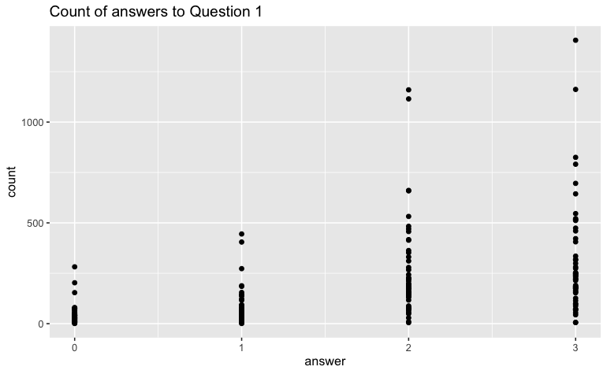

```r
ggplot(data = StudentQ1Summary, aes(x = answer, y = count)) + geom_point() +
  labs(title = "Count of answers to Question 1")
```

## MENTAL HEALTH TECH

```r
WorkStress <-
  #Creates a new data frame called WorkStress from MentalHealthTech
  MentalHealthTech %>%
   #answers for further analysis, and unreasonable ages
  filter(country == "United States", !is.na(state), seek_help != "Don't know",
         age <= 100, age > 0) %>%
  select(-timestamp, -country, -comments)  # Removes unneeded variables
```

Here, the gender was written very differently, so they were categorized into M,  
F, and other genders were deleted because there were very little values.

```r
WorkStress <-
  WorkStress %>%
  #Creates a unified name for "male"
  mutate(gender = replace(gender,
                          gender %in% c("Male-ish", "m", "M", "Cis Male",
                                        "male", "Male", "Man", "Male (CIS)",
                                        "cis male", "Male "), "M")) %>%
  #Creates a unified name for "female"
  mutate(gender = replace(gender,
                          gender %in% c("female", "f", "F", "Female (trans)",
                                        "Woman", "Female (cis)", "Cis Female",
                                        "woman", "Trans-female", "Trans woman",
                                        "Female", "Female "), "F")) %>%
  filter(gender %in% c("M", "F"))
```

```r
# using a for loop and if/else statement to change the range of employees to
# minimum employees
for (i in 1:nrow(WorkStress)) {
  #Any number of digits separated by a dash
  if (str_detect(WorkStress[i, "no_employees"], "^[:digit:]+-[:digit:]+$")) {
    WorkStress[i, "no_employees"] <- str_remove(WorkStress[i, "no_employees"],
                                                "^*(-[:digit:]+)$")
    #Remove everything after the dash including it
  } else {
    #removing everything that's not a number
    WorkStress[i, "no_employees"] <-
      str_remove_all(WorkStress[i, "no_employees"], "\\D+")
  }
}

WorkStress <-
  #Rename variable for clarity
  rename(WorkStress, min_employees = no_employees) %>%
  #Change variable from character to numeric
  mutate(min_employees = as.numeric(min_employees))
```

```r
WorkStress <-
  WorkStress %>%
    #Change "Yes" answers to 1
    mutate(seek_help = replace(seek_help, seek_help == "Yes", 1)) %>%
    #Change "No" answers to 0
    mutate(seek_help = replace(seek_help, seek_help == "No", 0)) %>%
    #Change variable from character to numeric
    mutate(seek_help = as.numeric(seek_help))
```

```r
#Calculate the averages for each variable by state
CareProvidedByState <-
  WorkStress %>%
  group_by(state) %>%
  summarise(mentalCareProvided = mean(seek_help) * 100,
            avgMinEmployee =mean(min_employees),
            avgAge = mean(age, na.rm = TRUE))
```

```r
# Creates a data frame for employees between ages 20 and 39, inclusive.
WorkStress2030 <-
  WorkStress %>%
  filter(age >= 20 & age < 40)
```

This graph shows that for females, as age increased, they viewed discussing  
mental health issues with employers wouldn’t have negative consequences, but  
there is an opposite trend for males.

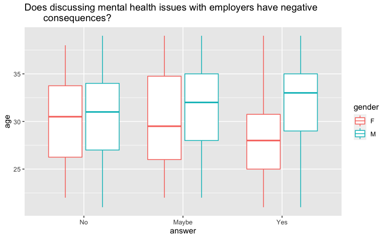

```r
WorkStress2030$mental_health_consequence <-
  factor(WorkStress2030$mental_health_consequence, levels =
           c("No","Maybe", "Yes"), ordered = TRUE)
# Orders the variable in the order of "No", "Maybe", then "Yes"
ggplot(data = WorkStress2030, aes(x = mental_health_consequence, y = age)) +
  geom_boxplot()  + aes(colour = gender) + theme(legend.position = "right") +
  labs(title = "Does discussing mental health issues with employers have negative
       consequences?", x = "answer")
```

## COMBINED

```r
Combined <-
  States %>%
  full_join(StudentStressByState, by = c("state" = "region"))
  #Join grouped data frame by state

Combined <-
  Combined %>%
  full_join(CareProvidedByState, by = c("abbreviation" = "state"))
  #Join grouped data frame by state to the same data frame as above
```

As the minimum employee count increase, the mental healthcare provided by tech  
companies increase. We can see that there is a positive correlation between the  
two variables.

```
Warning: Removed 7 rows containing non-finite values (stat_smooth).
Warning: Removed 7 rows containing missing values (geom_point).
```

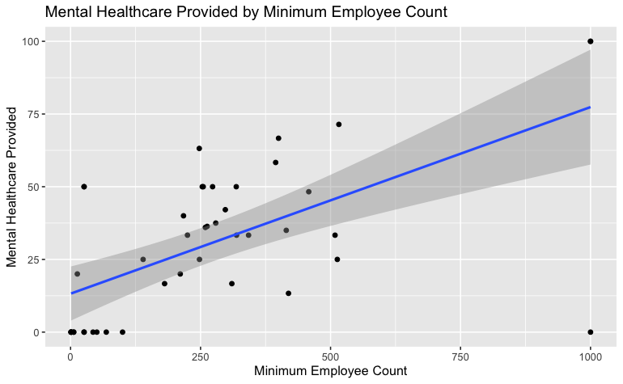

```r
ggplot(data = Combined, aes(x = avgMinEmployee, y = mentalCareProvided)) +
  geom_point()  + geom_smooth(method = lm) + theme(legend.position = "right") +
  labs(title = "Mental Healthcare Provided by Minimum Employee Count",
       x ="Minimum Employee Count", y ="Mental Healthcare Provided")
```

This graph shows the stress level of students by state where lighter colors  
represent higher levels of stress.

```
Mapping API still under development and may change in future releases.
```

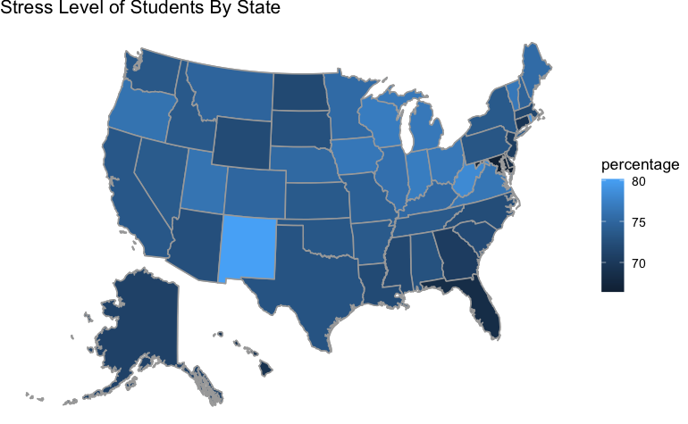

```r
mUSMap(Combined, key = "state", fill = "stressLevel") +
  labs(title = "Stress Level of Students By State", fill = "percentage")
```